# Chicago Geospatial Risk Modeling

Xingxing Shu

Nov 6, 2019

## 1.Setup

```r
library(tidyverse)
library(sf)
library(QuantPsyc)
library(RSocrata)
library(viridis)
library(caret)
library(spatstat)
library(spdep)
library(FNN)
library(grid)
library(gridExtra)
library(knitr)
library(kableExtra)
library(tidycensus)
library(raster)

mapTheme <- function(base_size = 12) {
  theme(
    text = element_text( color = "black"),
    plot.title = element_text(size = 14,colour = "black"),
    plot.subtitle=element_text(face="italic"),
    plot.caption=element_text(hjust=0),
    axis.ticks = element_blank(),
    panel.background = element_blank(),axis.title = element_blank(),
    axis.text = element_blank(),
    axis.title.x = element_blank(),
    axis.title.y = element_blank(),
    panel.grid.minor = element_blank(),
    panel.border = element_rect(colour = "black", fill=NA, size=2)
  )
}

nn_function <- function(measureFrom,measureTo,k) {
  measureFrom_Matrix <-
    as.matrix(measureFrom)
  measureTo_Matrix <-
    as.matrix(measureTo)
  nn <-
    get.knnx(measureTo, measureFrom, k)$nn.dist
    output <-
      as.data.frame(nn) %>%
      rownames_to_column(var = "thisPoint") %>%
      gather(points, point_distance, V1:ncol(.)) %>%
      arrange(as.numeric(thisPoint)) %>%
      group_by(thisPoint) %>%
      summarize(pointDistance = mean(point_distance)) %>%
      arrange(as.numeric(thisPoint)) %>%
      dplyr::select(-thisPoint) %>%
      pull()

  return(output)
}
```

## 2 Data Wrangling

All data in this analysis are downloaded from Chicago Open Data.The units of research is 500x500ft grid cells that overlaid Chicago City Limit. I’ll study on narcotics reported in 2018, try to predict it in each cell using following 8 variables:

Abandoned Buildings Abandoned Cars Graffiti Liquor Stores Street Light Outages Sanitation Issues Rodent Baitings Alley Light Outages

### 2.1 Boundary & Fishnets of Chicago

First download boundary of Chicago and make fishnets that cover it.

```r
chicagoBoundary <-
  st_read("E:/Chicago/riskPrediction_data/chicagoBoundary.shp") %>%
  st_transform(crs=102271)
```

```r
fishnet <-
  st_make_grid(chicagoBoundary, cellsize = 500) %>%
  st_sf()

fishnet <-
  fishnet[chicagoBoundary,] %>%
  mutate(uniqueID = rownames(.)) %>%
  dplyr::select(uniqueID)
```

### 2.2 Map of Outcome of Interest

I choose narcotics reported in 2018 in Chicago as the outcome of interest for it might be more report-biased than burglaries of Ken’s example.

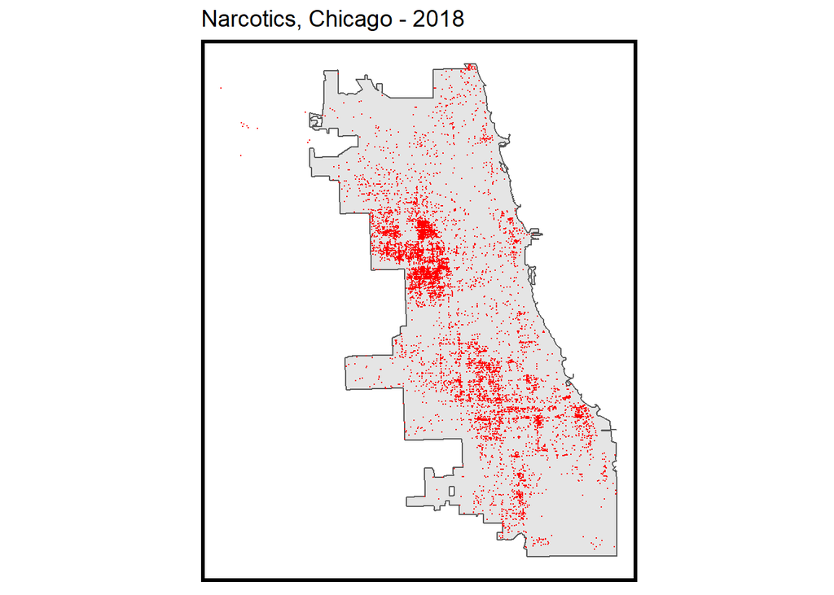

```r
Narcotic <-
  read.socrata("https://data.cityofchicago.org/Public-Safety/Crimes-2018/3i3m-jwuy") %>%
  filter(Primary.Type == "NARCOTICS") %>%
    dplyr::select(Y = Latitude, X = Longitude) %>%
  na.omit %>%
  st_as_sf(coords = c("X", "Y"), crs = 4326, agr = "constant")%>%
  st_transform(102271) %>%
  mutate(Legend = "narcotics")

ggplot() +
  geom_sf(data = chicagoBoundary) +
  geom_sf(data = Narcotic, colour="red", size=0.1, show.legend = "point") +
  labs(title= "Narcotics, Chicago - 2018") +
  mapTheme()
```

### 2.3 Fishnets of Narcotics

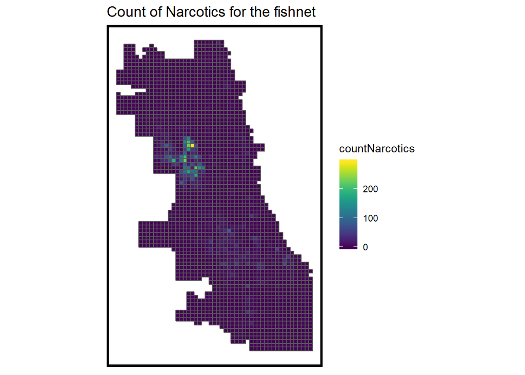

```r
Narcotic_net <-
  Narcotic %>%
  dplyr::select() %>%
  mutate(countNarcotics = 1) %>%
  aggregate(., fishnet, sum) %>%
  mutate(countNarcotics = ifelse(is.na(countNarcotics), 0, countNarcotics),
         uniqueID = rownames(.),
         cvID = sample(round(nrow(fishnet) / 24), size=nrow(fishnet), replace = TRUE))

ggplot() +
  geom_sf(data = Narcotic_net, aes(fill = countNarcotics)) +
  scale_fill_viridis() +
  labs(title = "Count of Narcotics for the fishnet") +
  mapTheme()
```

### 2.4 Plot Risk Factors

Two new predictors are added: Alley light outages and rodent baitings.

```r
abandonCars <-
  read.socrata("https://data.cityofchicago.org/Service-Requests/311-Service-Requests-Abandoned-Vehicles/3c9v-pnva") %>%
  mutate(year = substr(creation_date,1,4)) %>%
  filter(year == "2018") %>%
  dplyr::select(Y = latitude, X = longitude) %>%
  na.omit() %>%
  st_as_sf(coords = c("X", "Y"), crs = 4326, agr = "constant") %>%
  st_transform(st_crs(fishnet)) %>%
  mutate(Legend = "Abandoned_Cars")

abandonBuildings <-
  read.socrata("https://data.cityofchicago.org/Service-Requests/311-Service-Requests-Vacant-and-Abandoned-Building/7nii-7srd") %>%
    mutate(year = substr(date_service_request_was_received,1,4)) %>%
    filter(year == "2018") %>%
    filter(is_the_building_currently_vacant_or_occupied_ == "Vacant")%>%
    dplyr::select(Y = latitude, X = longitude) %>%
  na.omit() %>%
  st_as_sf(coords = c("X", "Y"), crs = 4326, agr = "constant") %>%
  st_transform(st_crs(fishnet)) %>%
  mutate(Legend = "Abandoned_Buildings")

graffiti <-
  read.socrata("https://data.cityofchicago.org/Service-Requests/311-Service-Requests-Graffiti-Removal-Historical/hec5-y4x5") %>%
    mutate(year = substr(creation_date,1,4)) %>%
    filter(year == "2018") %>%
    filter(where_is_the_graffiti_located_ == "Front" |
           where_is_the_graffiti_located_ == "Rear" | where_is_the_graffiti_located_ == "Side") %>%
    dplyr::select(Y = latitude, X = longitude) %>%
  na.omit() %>%
  st_as_sf(coords = c("X", "Y"), crs = 4326, agr = "constant") %>%
  st_transform(st_crs(fishnet)) %>%
  mutate(Legend = "Graffiti")

streetLightsOut <-
  read.socrata("https://data.cityofchicago.org/Service-Requests/311-Service-Requests-Street-Lights-All-Out/zuxi-7xem") %>%
    mutate(year = substr(creation_date,1,4)) %>%
    filter(year == "2018") %>%
    dplyr::select(Y = latitude, X = longitude) %>%
  na.omit() %>%
  st_as_sf(coords = c("X", "Y"), crs = 4326, agr = "constant") %>%
  st_transform(st_crs(fishnet)) %>%
  mutate(Legend = "Street_Lights_Out")

sanitation <-
  read.socrata("https://data.cityofchicago.org/Service-Requests/311-Service-Requests-Sanitation-Code-Complaints-Hi/me59-5fac") %>%
    mutate(year = substr(creation_date,1,4)) %>%
    filter(year == "2018") %>%
    dplyr::select(Y = latitude, X = longitude) %>%
  na.omit() %>%
  st_as_sf(coords = c("X", "Y"), crs = 4326, agr = "constant") %>%
  st_transform(st_crs(fishnet)) %>%
  mutate(Legend = "Sanitation")

liquorRetail <-
  read.socrata("https://data.cityofchicago.org/Community-Economic-Development/Business-Licenses-Cur   rent-Liquor-and-Public-Places/nrmj-3kcf") %>%
  filter(BUSINESS.ACTIVITY == "Retail Sales of Packaged Liquor") %>%
  dplyr::select(Y = LATITUDE, X = LONGITUDE) %>%
  na.omit() %>%
  st_as_sf(coords = c("X", "Y"), crs = 4326, agr = "constant") %>%
  st_transform(st_crs(fishnet)) %>%
  mutate(Legend = "Liquor_Retail")

rodentBaits <-
  read.socrata("https://data.cityofchicago.org/Service-Requests/311-Service-Requests-Rodent-Baiting-Historical/97t6-zrhs") %>%
    mutate(year = substr(creation_date,1,4)) %>%
    filter(year == "2018") %>%
    dplyr::select(Y = latitude, X = longitude) %>%
  na.omit() %>%
  st_as_sf(coords = c("X", "Y"), crs = 4326, agr = "constant") %>%
  st_transform(st_crs(fishnet)) %>%
  mutate(Legend = "Rodent_Baiting")

alleyLightsOut <-
  read.socrata("https://data.cityofchicago.org/Service-Requests/311-Service-Requests-Alley-Lights-Out-Historical/t28b-ys7j") %>%
    mutate(year = substr(creation_date,1,4)) %>%
    filter(year == "2018") %>%
    dplyr::select(Y = latitude, X = longitude) %>%
  na.omit() %>%
  st_as_sf(coords = c("X", "Y"), crs = 4326, agr = "constant") %>%
  st_transform(st_crs(fishnet)) %>%
  mutate(Legend = "Alley_Lights_Out")
```

Next, a small multiple map of the each of these risk factors is plotted below as points.

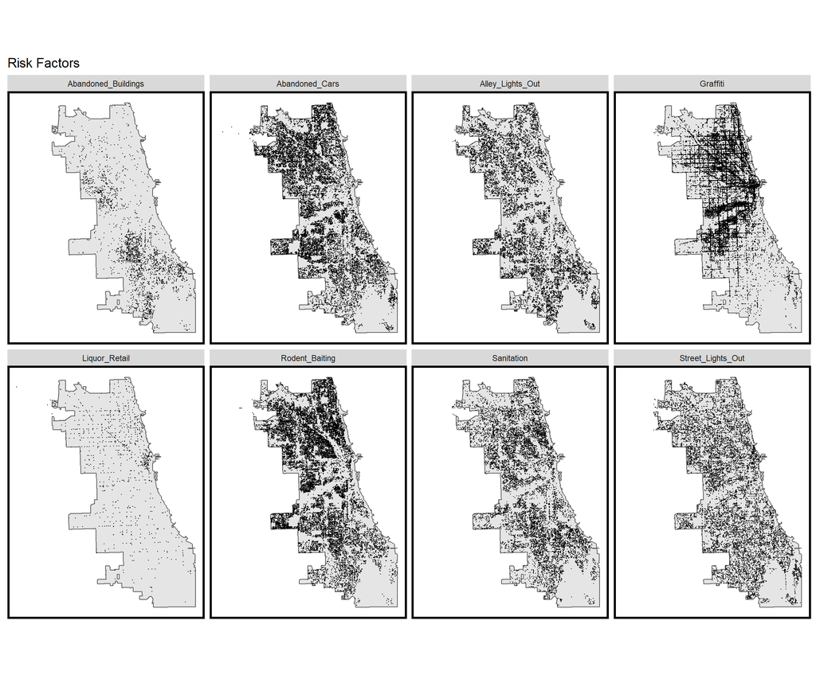

```r
ggplot() +
  geom_sf(data=chicagoBoundary) +
  geom_sf(data = rbind(abandonCars,streetLightsOut,abandonBuildings,
                      liquorRetail, graffiti, sanitation,alleyLightsOut,rodentBaits),
         size = .1) +
  facet_wrap(~Legend, ncol = 4) +
  labs(title = "Risk Factors") +
  mapTheme()
```

## 3. Feature Engeneering

### 3.1 Risk Factors Count by Cells

```r
vars_net <-
  rbind(abandonCars,streetLightsOut,abandonBuildings,
        liquorRetail, graffiti, sanitation,alleyLightsOut,rodentBaits) %>%
  st_join(., fishnet, join=st_within) %>%
  st_set_geometry(NULL) %>%
  group_by(uniqueID, Legend) %>%
  summarize(count = n()) %>%
  full_join(fishnet) %>%
  spread(Legend, count, fill=0) %>%
  st_sf() %>%
  dplyr::select(-`<NA>`) %>%
  na.omit()

vars_net.long <-
  vars_net %>%
  gather(Variable, value, -geometry, -uniqueID)

vars <- unique(vars_net.long$Variable)
mapList <- list()

for(i in vars){
  mapList[[i]] <-
    ggplot() +
      geom_sf(data = filter(vars_net.long, Variable == i), aes(fill=value), colour=NA) +
      scale_fill_viridis(name="") +
      labs(title=i) +
      mapTheme()}
```

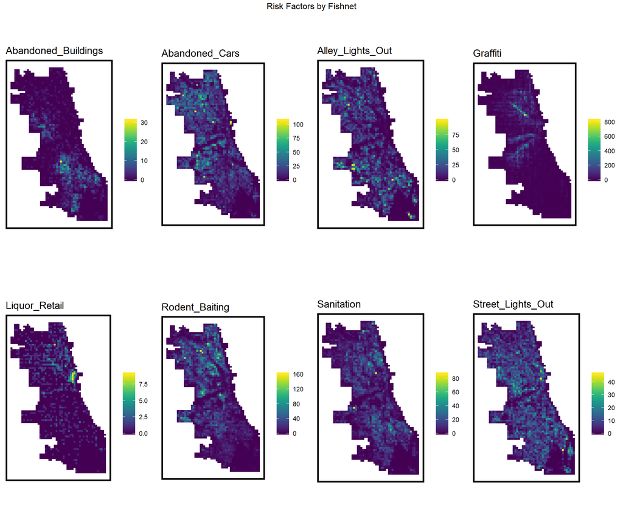

```r
do.call(grid.arrange,c(mapList, ncol = 4, top = "Risk Factors by Fishnet"))
```

### 3.2 Nearest neighbor features

Here shows the maps of the average distance by 5 nearest risk factors to get a bettercunderstanding of local exposure to risk factors.

[figure not shown]

```r
do.call(grid.arrange,c(mapList, ncol =4, top = "Nearest Neighbor risk Factors by Fishnet"))
```

### 3.3 Distance to CBD

```r
neighborhoods <-
  st_read("https://raw.githubusercontent.com/blackmad/neighborhoods/master/chicago.geojson") %>%
  st_transform(st_crs(fishnet))
loopPoint <-
  neighborhoods %>%
  filter(name == "Loop") %>%
  st_centroid()

vars_net$loopDistance =
  st_distance(st_centroid(vars_net),loopPoint) %>%
  as.numeric()
```

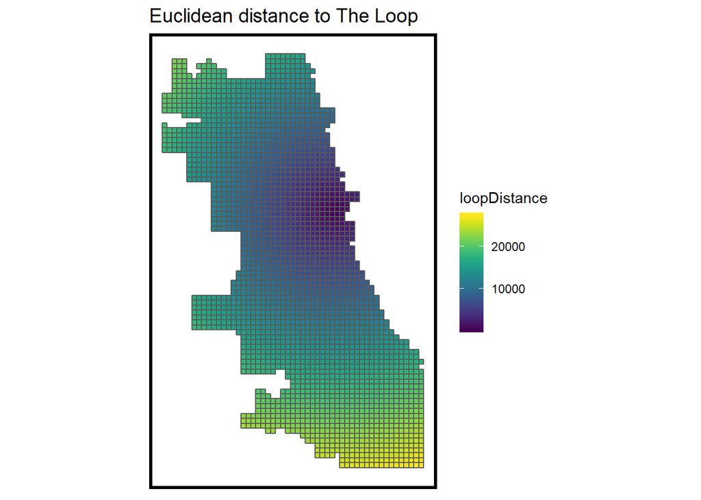

```r
ggplot() +
  geom_sf(data=vars_net, aes(fill=loopDistance)) +
  scale_fill_viridis() +
  labs(title="Euclidean distance to The Loop") +
  mapTheme()
```

### 3.4 Create final_net

Join risk factors to narcotics in a final fishnet. We also join the neighborhoods to the fishnet for spatial cross-validation purposes.

```r
final_net <-
  left_join(Narcotic_net, st_set_geometry(vars_net, NULL), by="uniqueID")

final_net <-
  st_centroid(final_net) %>%
    st_join(., dplyr::select(neighborhoods, name)) %>%
      st_set_geometry(NULL) %>%
      left_join(dplyr::select(final_net, geometry, uniqueID)) %>%
      st_sf() %>%
  na.omit()
```

## 4. Exploring Spatial Structure of Narcotics

### 4.1 Local Moran’s I

Local Moran’s I helps to identify statistically significant instances of clustering in a spatial dataset and the null hypothesis for it is that the count of narcotics is randomly distributed across the space. We see hotspots concentrated on the west side of CBD and some others locate in southern part.

```r
final_net.nb <- poly2nb(final_net, queen=TRUE)
final_net.weights <- nb2listw(final_net.nb, style="W", zero.policy=TRUE)

final_net.localMorans <-
  cbind(
    as.data.frame(localmoran(final_net$countNarcotics, final_net.weights)),
    as.data.frame(final_net, NULL)) %>%
    st_sf() %>%
    dplyr::select(Narcotic_Count = countNarcotics,
                  Local_Morans_I = Ii,
                  P_Value = `Pr(z > 0)`) %>%
    mutate(Significant_Hotspots = ifelse(P_Value <= 0.05, 1, 0)) %>%
    gather(Variable, Value, -geometry)

vars <- unique(final_net.localMorans$Variable)
varList <- list()

for(i in vars){
  varList[[i]] <-
    ggplot() +
      geom_sf(data = filter(final_net.localMorans, Variable == i), aes(fill = Value), colour=NA) +
      scale_fill_viridis(name="") +
      labs(title=i) +
      mapTheme()}
```

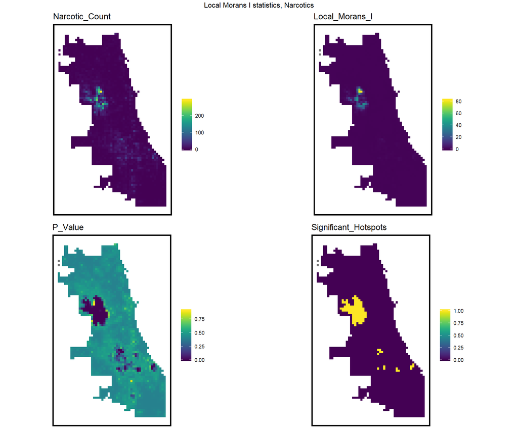

```r
do.call(grid.arrange,c(varList, ncol = 2, top = "Local Morans I statistics, Narcotics"))
```

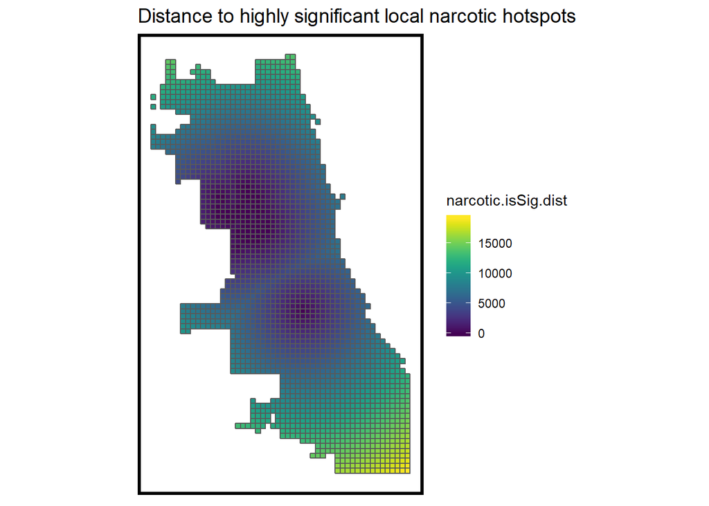

```r
final_net <-
  final_net %>%
  mutate(narcotic.isSig = ifelse(localmoran(final_net$countNarcotics,
                                            final_net.weights)[,5] <= 0.0000001, 1, 0)) %>%
  mutate(narcotic.isSig.dist = nn_function(st_coordinates(st_centroid(final_net)),
                                           st_coordinates(st_centroid(
                                             filter(final_net, narcotic.isSig == 1))), 1 ))

ggplot() +
  geom_sf(data = final_net, aes(fill = narcotic.isSig.dist)) +
  scale_fill_viridis() +
  labs(title = "Distance to highly significant local narcotic hotspots") +
  mapTheme()
```

### 4.2 Correlation tests

Correlation test is used to check the relationship between narcotic counts and risk factors.

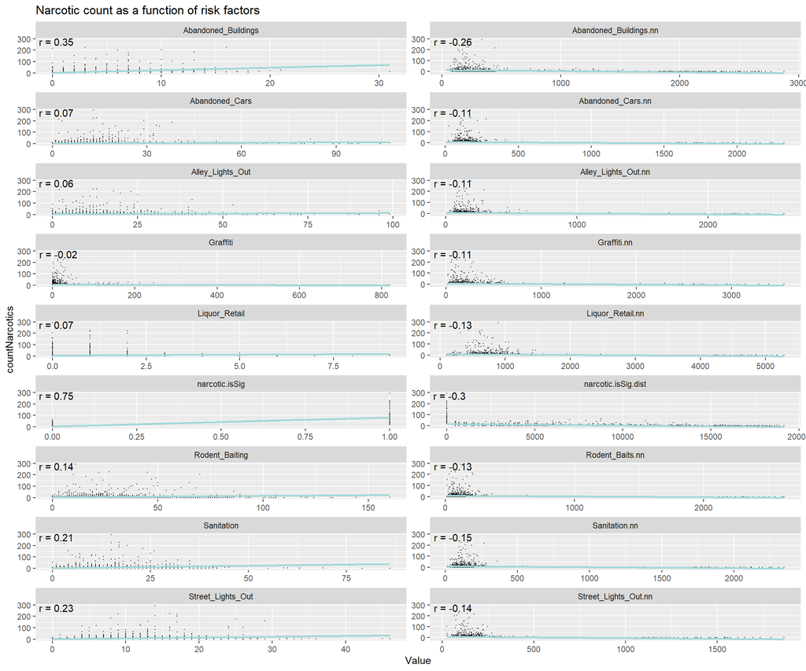

```r
correlation.long <-
  st_set_geometry(final_net, NULL) %>%
    dplyr::select(-uniqueID, -cvID, -loopDistance,-name) %>%
    gather(Variable, Value, -countNarcotics)

correlation.cor <-
  correlation.long %>%
    group_by(Variable) %>%
    summarize(correlation = cor(Value, countNarcotics, use = "complete.obs"))

ggplot(correlation.long, aes(Value, countNarcotics)) +
  geom_point(size = 0.1) +
  geom_text(data = correlation.cor, aes(label = paste("r =", round(correlation, 2))),
            x=-Inf, y=Inf, vjust = 1, hjust = -.1) +
  geom_smooth(method = "lm", se = FALSE, colour = "#a2d7d8") +
  facet_wrap(~Variable, ncol = 2, scales = "free") +
  labs(title = "Narcotic count as a function of risk factors")
```

## 5.Poisson Regression

The histogram below shows the distribution of narcotics in the grid cells is obviously right skewed. The distribution resembles a Poisson distribution, which we’ll use in our regression model.

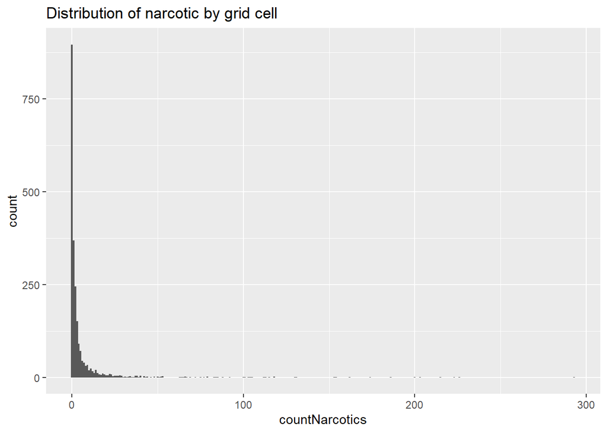

```r
ggplot(final_net, aes(countNarcotics)) +
  geom_histogram(binwidth = 1) +
  labs(title = "Distribution of narcotic by grid cell")
```

### 5.1 Cross-validated poisson Regression

```r
reg.vars <- c("Abandoned_Buildings.nn", "Abandoned_Cars.nn", "Graffiti.nn", "Alley_Lights_Out.nn",
              "Liquor_Retail.nn", "Street_Lights_Out.nn", "Sanitation.nn", "loopDistance","Rodent_Baits.nn")

reg.ss.vars <- c("Abandoned_Buildings.nn", "Abandoned_Cars.nn", "Graffiti.nn", "Alley_Lights_Out.nn",
              "Liquor_Retail.nn", "Street_Lights_Out.nn", "Sanitation.nn", "loopDistance","Rodent_Baits.nn",
                 "narcotic.isSig", "narcotic.isSig.dist")

crossValidate <- function(dataset, id, dependentVariable, indVariables) {

allPredictions <- data.frame()
cvID_list <- unique(dataset[[id]])

for (i in cvID_list) {

  thisFold <- i
  cat("This hold out fold is", thisFold, "\n")

  fold.train <- filter(dataset, dataset[[id]] != thisFold) %>% as.data.frame() %>%
                dplyr::select(id, geometry, indVariables, dependentVariable)
  fold.test  <- filter(dataset, dataset[[id]] == thisFold) %>% as.data.frame() %>%
                dplyr::select(id, geometry, indVariables, dependentVariable)

  regression <-
    glm(countNarcotics ~ ., family = "poisson",
      data = fold.train %>%
      dplyr::select(-geometry, -id))

  thisPrediction <-
    mutate(fold.test, Prediction = predict(regression, fold.test, type = "response"))

  allPredictions <-
    rbind(allPredictions, thisPrediction)

  }
  return(st_sf(allPredictions))
}

reg.cv <- crossValidate(
  dataset = final_net,
  id = "cvID",
  dependentVariable = "countNarcotics",
  indVariables = reg.vars) %>%
    dplyr::select(cvID = cvID, countNarcotics, Prediction, geometry)

reg.ss.cv <- crossValidate(
  dataset = final_net,
  id = "cvID",
  dependentVariable = "countNarcotics",
  indVariables = reg.ss.vars) %>%
    dplyr::select(cvID = cvID, countNarcotics, Prediction, geometry)

reg.spatialCV <- crossValidate(
  dataset = final_net,
  id = "name",
  dependentVariable = "countNarcotics",
  indVariables = reg.vars) %>%
    dplyr::select(cvID = name, countNarcotics, Prediction, geometry)

reg.ss.spatialCV <- crossValidate(
  dataset = final_net,
  id = "name",
  dependentVariable = "countNarcotics",
  indVariables = reg.ss.vars) %>%
    dplyr::select(cvID = name, countNarcotics, Prediction, geometry)
```

## 6. Generalizibility by Neighborhoods

### 6.1 Maps of Model Predictions

Here are the maps of prediction of each Regression.It indicates that the models with spatial structural features does a better job than just risk factors considered.

```r
reg.summary <-
  rbind(
    mutate(reg.cv,           Error = countNarcotics - Prediction,
                             Regression = "Random k-fold CV: Just Risk Factors"),

    mutate(reg.ss.cv,        Error = countNarcotics - Prediction,
                             Regression = "Random k-fold CV: Spatial Structure"),

    mutate(reg.spatialCV,    Error = countNarcotics - Prediction,
                             Regression = "Spatial LOGO-CV: Just Risk Factors"),

    mutate(reg.ss.spatialCV, Error = countNarcotics - Prediction,
                             Regression = "Spatial LOGO-CV: Spatial Structure")) %>%
    st_sf()
```

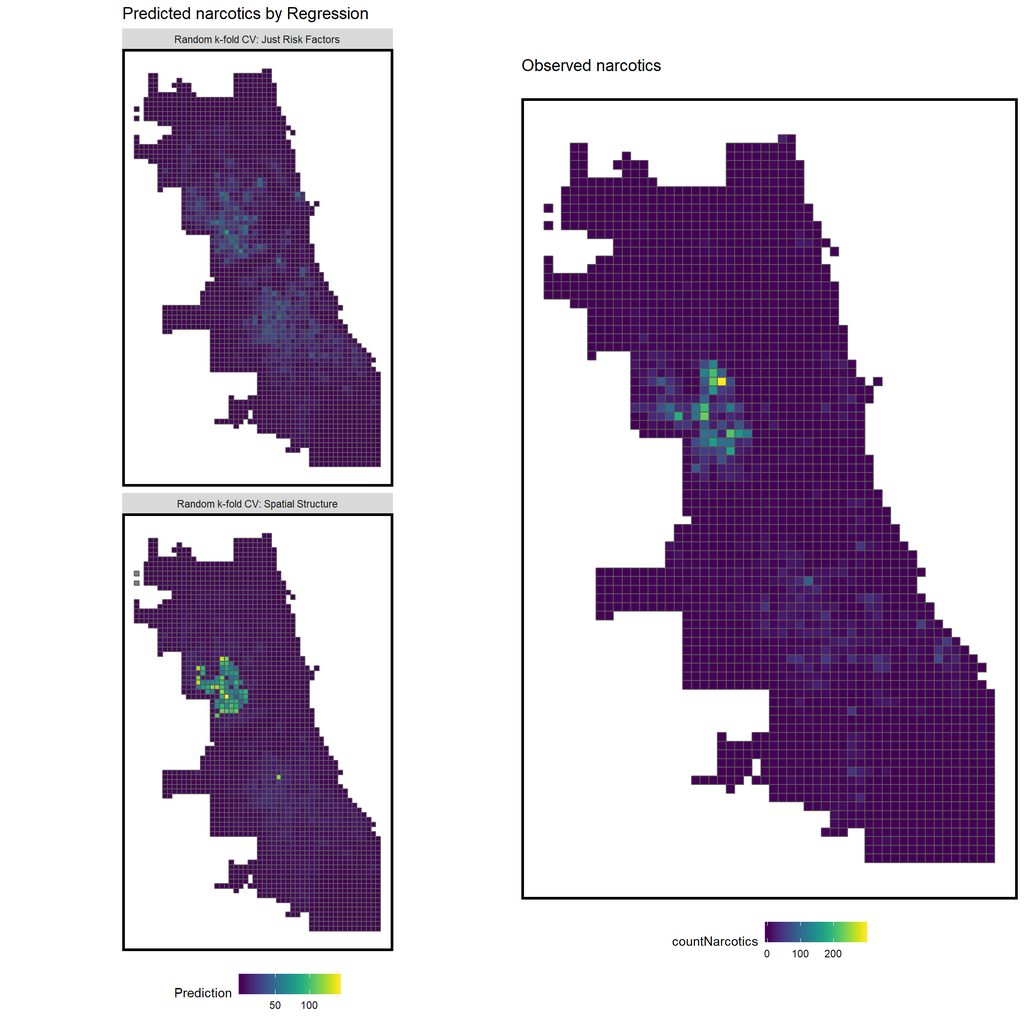

```r
grid.arrange(
  reg.summary %>%
    filter(Regression == "Random k-fold CV: Just Risk Factors" |
             Regression == "Random k-fold CV: Spatial Structure") %>%
    ggplot() +
      geom_sf(aes(fill = Prediction)) +
      facet_wrap(~Regression,ncol = 1) +
      scale_fill_viridis() +
      labs(title = "Predicted narcotics by Regression") +
      mapTheme() + theme(legend.position="bottom"),

  filter(reg.summary, Regression == "Random k-fold CV: Just Risk Factors") %>%
    ggplot() +
      geom_sf(aes(fill = countNarcotics)) +
      scale_fill_viridis() +
      labs(title = "Observed narcotics\n") +
      mapTheme() + theme(legend.position="bottom"), ncol = 2)
```

### 6.2 Maps of Model Errors

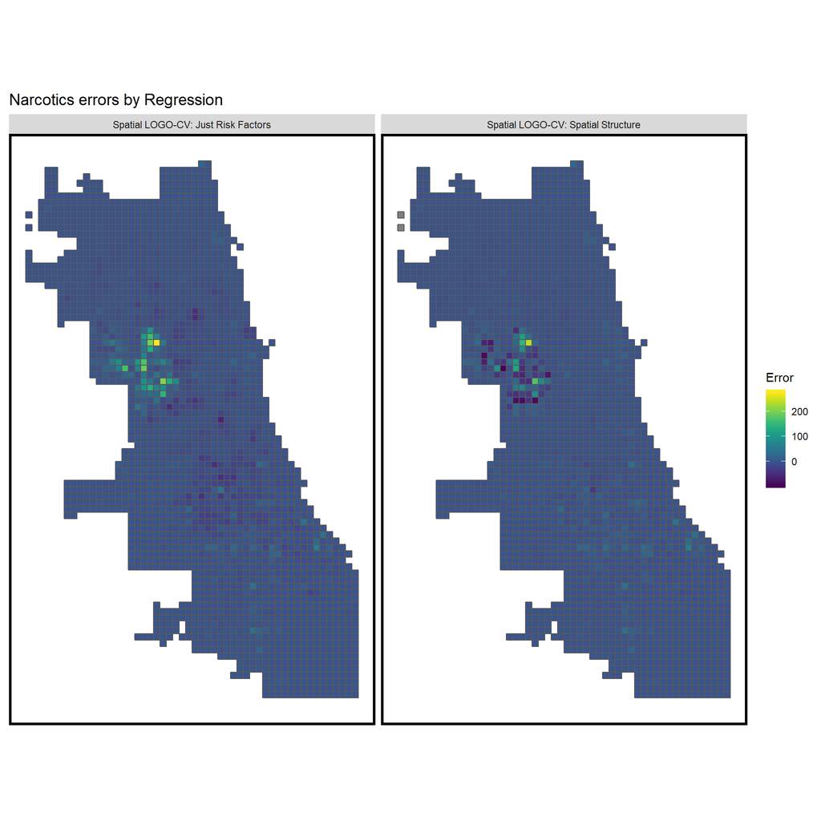

```r
filter(reg.summary, Regression == "Spatial LOGO-CV: Just Risk Factors" |
         Regression == "Spatial LOGO-CV: Spatial Structure") %>%
  ggplot() +
    geom_sf(aes(fill = Error)) +
    facet_wrap(~Regression) +
    scale_fill_viridis() +
    labs(title = "Narcotics errors by Regression") +
    mapTheme()
```

### 6.3 Table of MAE & Sd of MAE

Mean absolute error (MAE) is calculated on predicted and observed narcotics and compared. The results indicate that the Spatial Structure model can decrease the MAE and SD_MAE. So,the regressions with the spatial structural features are more accurate .

```r
st_set_geometry(reg.summary, NULL) %>%
  group_by(Regression) %>%
  summarize(MAE = round(mean(abs(Prediction - countNarcotics), na.rm = T),2),
            SD_MAE = round(sd(abs(Prediction - countNarcotics), na.rm = T),2)) %>%
  kable(caption = "MAE by regression") %>%
    kable_styling("striped", full_width = F) %>%
    row_spec(1, color = "white", background = "#C85B6C") %>%
    row_spec(3, color = "white", background = "#C85B6C") %>%
    row_spec(2, color = "white", background = "#315B8A") %>%
    row_spec(4, color = "white", background = "#315B8A")
```

MAE by regression

| Regression | MAE | SD_MAE |
| --- | --- | --- |
| Random k-fold CV: Just Risk Factors | 5.43 | 14.98 |
| Random k-fold CV: Spatial Structure | 3.98 | 11.41 |
| Spatial LOGO-CV: Just Risk Factors | 5.63 | 15.50 |
| Spatial LOGO-CV: Spatial Structure | 4.09 | 11.74 |

### 6.4 Table of Raw Errors by Race Context

```r
readRenviron("~/.Renviron")
census_api_key('b08efd70bfab76bb99f80a09321c3a90251fbe4b', overwrite = TRUE, install = TRUE)
```

```
## [1] "b08efd70bfab76bb99f80a09321c3a90251fbe4b"
```

```r
tracts17 <-
  get_acs(geography = "tract", variables = c("B01001_001E","B01001A_001E"),
          year = 2017, state=17, county=031, geometry=T) %>%
  st_transform(102271)  %>%
  dplyr::select(variable, estimate, GEOID) %>%
  spread(variable, estimate) %>%
  rename(TotalPop = B01001_001,
         NumberWhites = B01001A_001) %>%
  mutate(percentWhite = NumberWhites / TotalPop,
         raceContext = ifelse(percentWhite > .5, "Majority_White", "Majority_Non_White")) %>%
  .[neighborhoods,]
final_reg <-
  filter(reg.summary, Regression == "Spatial LOGO-CV: Spatial Structure" |
           Regression == "Spatial LOGO-CV: Just Risk Factors" |
           Regression == "Random k-fold CV: Just Risk Factors" |
           Regression == "Random k-fold CV: Spatial Structure") %>%
  mutate(uniqueID = rownames(.))

final_reg.tracts <-
  st_join(st_centroid(final_reg), tracts17) %>%
    st_set_geometry(NULL) %>%
    left_join(dplyr::select(final_reg, uniqueID)) %>%
    st_sf() %>%
    na.omit()

st_set_geometry(final_reg.tracts, NULL) %>%
  group_by(Regression, raceContext) %>%
  summarize(mean.Error = mean(Error, na.rm = T)) %>%
  spread(raceContext, mean.Error) %>%
  kable(caption = "Mean Error by neighborhood racial context") %>%
    kable_styling("striped", full_width = F) %>%
    row_spec(1, color = "white", background = "#C85B6C") %>%
    row_spec(3, color = "white", background = "#C85B6C") %>%
    row_spec(2, color = "white", background = "#315B8A") %>%
    row_spec(4, color = "white", background = "#315B8A")
```

Mean Error by neighborhood racial context

| Regression | Majority_Non_White | Majority_White |
| --- | --- | --- |
| Random k-fold CV: Just Risk Factors | 1.5863570 | -1.7047096 |
| Random k-fold CV: Spatial Structure | 0.5262607 | -0.5952995 |
| Spatial LOGO-CV: Just Risk Factors | 1.7409424 | -1.7870055 |
| Spatial LOGO-CV: Spatial Structure | 0.5220311 | -0.6180187 |

## 7.Comparison of Kernel Density and Risk Predictions

### 7.1 Map of Kernel Density to Risk Predictions

The following plots compared the risk predictions and kernel density.From the two plots, some parts in kernel density map have high risk while in risk prediction map they are below average means that kernel density overpredict narcotics in those regions, which indicates that the risk prediction model can achieve more detailed predictions.

```r
narc_ppp <- as.ppp(st_coordinates(Narcotic), W = st_bbox(final_net))
narc_KD <- spatstat::density.ppp(narc_ppp, 1000)

narc_KDE_sf <- as.data.frame(narc_KD) %>%
  st_as_sf(coords = c("x", "y"), crs = st_crs(final_net)) %>%
  aggregate(., final_net, mean) %>%

  mutate(label = "Kernel Density",
         Risk_Category = ntile(value, 100),
         Risk_Category = case_when(
           Risk_Category >= 90 ~ "90% to 100%",
           Risk_Category >= 70 & Risk_Category <= 89 ~ "70% to 89%",
           Risk_Category >= 50 & Risk_Category <= 69 ~ "50% to 69%",
           Risk_Category >= 30 & Risk_Category <= 49 ~ "30% to 49%",
           Risk_Category >= 1 & Risk_Category <= 29 ~ "1% to 29%")) %>%

  bind_cols(
    aggregate(
      dplyr::select(Narcotic) %>% mutate(narcCount = 1), ., length) %>%
    mutate(narcCount = replace_na(narcCount, 0))) %>%

  dplyr::select(label, Risk_Category, narcCount)

narc_risk_sf <-
  filter(final_reg, Regression == "Spatial LOGO-CV: Spatial Structure") %>%
  mutate(label = "Risk Predictions",
         Risk_Category = ntile(Prediction, 100),
         Risk_Category = case_when(
           Risk_Category >= 90 ~ "90% to 100%",
           Risk_Category >= 70 & Risk_Category <= 89 ~ "70% to 89%",
           Risk_Category >= 50 & Risk_Category <= 69 ~ "50% to 69%",
           Risk_Category >= 30 & Risk_Category <= 49 ~ "30% to 49%",
           Risk_Category >= 1 & Risk_Category <= 29 ~ "1% to 29%")) %>%
  bind_cols(
    aggregate(
      dplyr::select(Narcotic) %>% mutate(narcCount = 1), ., length) %>%
      mutate(narcCount = replace_na(narcCount, 0))) %>%
  dplyr::select(label,Risk_Category, narcCount)
```

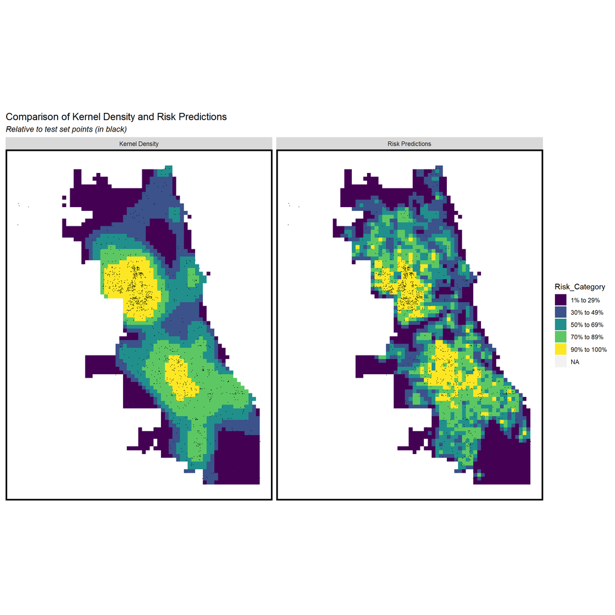

```r
rbind(narc_KDE_sf, narc_risk_sf) %>%
  gather(Variable, Value, -label, -Risk_Category, -geometry) %>%
  ggplot() +
    geom_sf(aes(fill = Risk_Category), colour = NA) +
    geom_sf(data = sample_n(Narcotic, 1500), size = .1, colour = "black") +
    facet_wrap(~label, ) +
    scale_fill_viridis(discrete = TRUE) +
    labs(title="Comparison of Kernel Density and Risk Predictions",
         subtitle="Relative to test set points (in black)") +
    mapTheme()
```

### 7.2 Bar Plot of Kernel Density to Risk Predictions

The barchart shows the rate of narcotics by risk category and model type.It shows risk prediction model have higher share of the rate of narcotics of high_risk category, means the risk prediction model is better than kernel density model.

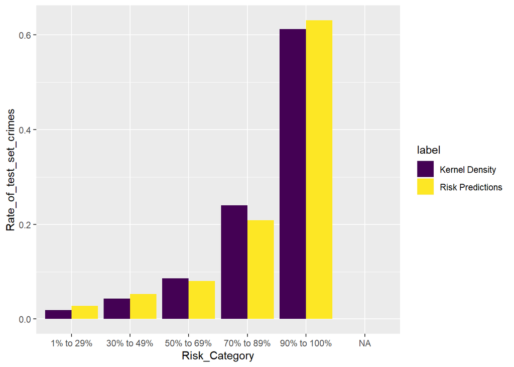

```r
rbind(narc_KDE_sf, narc_risk_sf) %>%
  st_set_geometry(NULL) %>%
  gather(Variable, Value, -label, -Risk_Category) %>%
  group_by(label, Risk_Category) %>%
  summarize(countNarcotics = sum(Value)) %>%
  ungroup() %>%
  group_by(label) %>%
  mutate(Rate_of_test_set_crimes = countNarcotics / sum(countNarcotics)) %>%
    ggplot(aes(Risk_Category,Rate_of_test_set_crimes)) +
      geom_bar(aes(fill=label), position="dodge", stat="identity") +
      scale_fill_viridis(discrete = TRUE)
```